# Recommender Systems In Context: Health Recommender Systems

Amber Ferger  
6/30/2020

### What is an HRS?

**Health Recommender System**

[figure not shown]

- Provides recommendations on diagnosis/treatment given diagnosis search

### The Problem with self-searches

[figure not shown]

- Findability, Comprehendability, Reliability

### The Solution: Personalized Health Recommendation Systems

**Personalized based on personal medical history**

User Profile : individual health data (Personal Health Record - PHR)

Recommended Items: medically accepted & **verified** information

- How to cope with a disease
- Disease definitions
- Care Plans
- Educational materials for healthier living

### Who can use it & how?

**Health professional**:

- Retrieve relevant information for a patient
- Educational materials linked to patient conditions
- Clinical guidelines & research

**Patient**:

- Layman-friendly content for disease understanding & care

### System structure

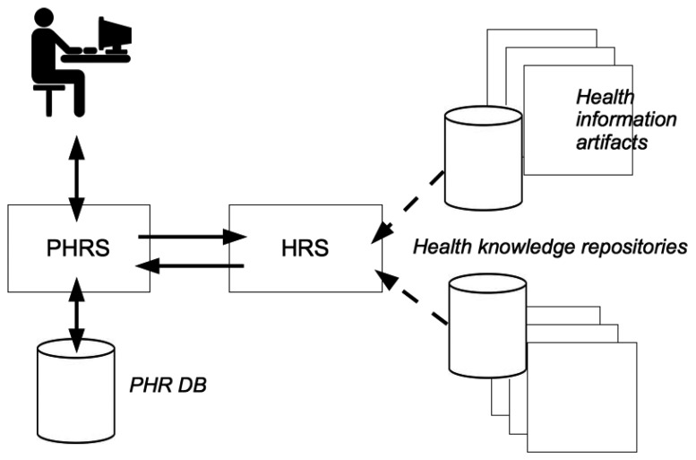

### The Recommendations

**Content-based collaborative filtering**

- High degree of confidentiality of patient conditions
- User's personal data used for recommendations
- Document ranking

**Sources:**

- Electronic Health Records - NLP, Entity Extraction
- Insurance Claims - explicit diagnoses

**Evaluation**

- Health professionals assess the recommendations

### Benefits

- Patient-centric information
- Validated, relevant information
- Better understanding (layman friendly) & safer outcomes
- All user conditions taken into account (drug interactions)
- No info overload!

### Resources

- Wiesner M, Pfeifer D. Health recommender systems: concepts, requirements, technical basics and challenges. Int J Environ Res Public Health. 2014;11(3):2580-2607. Published 2014 Mar 3. doi:10.3390/ijerph110302580